# Final Project

## Andrey McLeggan

### 4Dec2024

#### Q1

```python
import pandas as pd
s = pd.read_csv("social_media_usage.csv")
print(s.shape)
```

```
(1502, 89)
```

#### Q2

```python
import numpy as np
def clean_sm(x):
    return np.where(x == 1, 1, 0)
```

```python
toy_data = pd.DataFrame({
    'column1': [1, 0, 2],
    'column2': [1, 3, 1]
})
```

```python
toy_data
```

|  | column1 | column2 |
| --- | --- | --- |
| 0 | 1 | 1 |
| 1 | 0 | 3 |
| 2 | 2 | 1 |

```python
cleaned_toy_data = clean_sm(toy_data)
```

```python
cleaned_toy_data
```

```
array([[1, 1],
       [0, 0],
       [0, 1]])
```

#### Q3

```python
import matplotlib.pyplot as plt
filtered_data = s[(s['income'] <= 9) & (s['educ2'] <= 8) & (s['age'] <= 98)]

ss = filtered_data[['income', 'educ2', 'par', 'marital', 'sex', 'age']].copy()
ss.rename(columns={'educ2': 'education', 'par': 'parent', 'marital': 'married', 'sex': 'female'}, inplace=True)

ss['female'] = np.where(ss['female'] == 2, 1, 0)

ss['sm_li'] = clean_sm(filtered_data['web1h'])
```

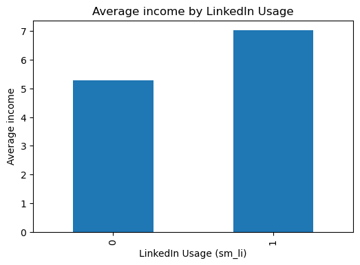

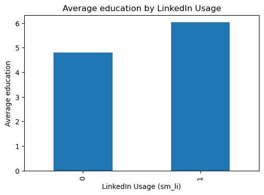

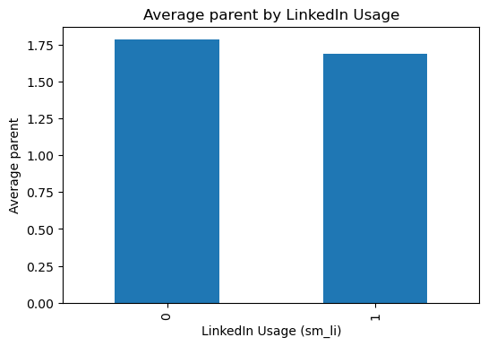

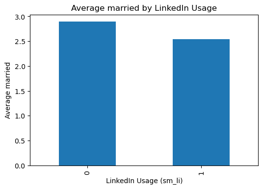

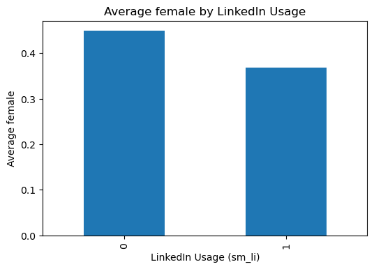

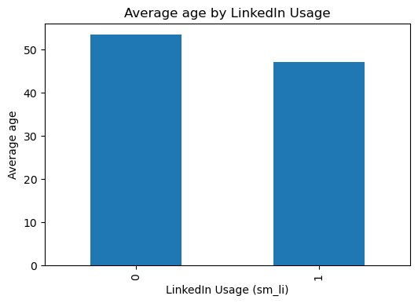

```python
ss = ss.dropna()

for column in ss.columns[:-1]:
    plt.figure(figsize=(6, 4))
    ss.groupby('sm_li')[column].mean().plot(kind='bar')
    plt.title(f"Average {column} by LinkedIn Usage")
    plt.ylabel(f"Average {column}")
    plt.xlabel("LinkedIn Usage (sm_li)")
    plt.show()
```

```python
ss.head(10)
```

|  | income | education | parent | married | female | age | sm_li |
| --- | --- | --- | --- | --- | --- | --- | --- |
| 0 | 6 | 4 | 2 | 5 | 1 | 77 | 0 |
| 1 | 5 | 3 | 2 | 6 | 0 | 59 | 0 |
| 2 | 8 | 4 | 2 | 1 | 1 | 60 | 0 |
| 3 | 8 | 8 | 2 | 6 | 0 | 73 | 0 |
| 4 | 7 | 8 | 2 | 1 | 1 | 65 | 1 |
| 5 | 7 | 6 | 2 | 3 | 1 | 62 | 0 |
| 6 | 7 | 4 | 2 | 1 | 1 | 70 | 0 |
| 7 | 3 | 6 | 2 | 5 | 0 | 94 | 0 |
| 8 | 3 | 3 | 2 | 1 | 1 | 65 | 0 |
| 10 | 9 | 8 | 2 | 6 | 1 | 55 | 1 |

#### Q4

```python
y = ss['sm_li']
x = ss.drop(columns=['sm_li'])
print(y.head)
```

```
<bound method NDFrame.head of 0       0
1       0
2       0
3       0
4       1
       ..
1497    0
1498    1
1499    0
1500    0
1501    0
Name: sm_li, Length: 1260, dtype: int32>
```

```python
print(x.head)
```

```
<bound method NDFrame.head of       income  education  parent  married  female  age
0          6          4       2        5       1   77
1          5          3       2        6       0   59
2          8          4       2        1       1   60
3          8          8       2        6       0   73
4          7          8       2        1       1   65
...      ...        ...     ...      ...     ...  ...
1497       6          4       1        1       0   41
1498       2          5       2        2       0   46
1499       7          3       2        6       0   18
1500       4          3       2        6       1   23
1501       4          3       1        1       0   50

[1260 rows x 6 columns]>
```

#### Q5

```python
from sklearn.model_selection import train_test_split

X_train, X_test, y_train, y_test = train_test_split(X, y, test_size=0.2, random_state=42)
```

#### X_train: Feature set for training (80% of data). Used by the model to learn patterns during training.

#### X_test: Feature set for testing (20% of data). Used to evaluate the model's performance on unseen data.

#### y_train: Target vector for training (80% of data). Provides the true labels for supervised learning.

#### y_test: Target vector for testing (20% of data). Used to measure the model's predictive accuracy.

#### Q6

```python
from sklearn.linear_model import LogisticRegression

log_reg = LogisticRegression(class_weight='balanced', random_state=42)
log_reg.fit(X_train, y_train)
```

```
LogisticRegression(class_weight='balanced', random_state=42)
```

#### Q7

```python
from sklearn.metrics import accuracy_score, confusion_matrix, ConfusionMatrixDisplay

y_pred = log_reg.predict(X_test)
accuracy = accuracy_score(y_test, y_pred)
print(f"Model Accuracy: {accuracy:.2f}")
```

```
Model Accuracy: 0.66
```

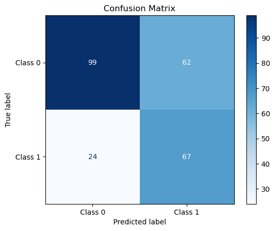

```python
conf_matrix = confusion_matrix(y_test, y_pred)
ConfusionMatrixDisplay(conf_matrix, display_labels=["Class 0", "Class 1"]).plot(cmap="Blues")
plt.title("Confusion Matrix")
plt.show()
```

#### Actual Positive/Predictive Negative is 24, meaning the model predicted 24 instances of non-linkedin users that were infact linkedin users

#### Actual Positive/Predicted Positive is 67, meaning the model predicted 67 users that were infact users

#### Q8

```python
conf_matrix = confusion_matrix(y_test, y_pred)

conf_matrix_df = pd.DataFrame(
    conf_matrix,
    index=["Actual Negative", "Actual Positive"],
    columns=["Predicted Negative", "Predicted Positive"]
)
print(conf_matrix_df)
```

```
                 Predicted Negative  Predicted Positive
Actual Negative                  99                  62
Actual Positive                  24                  67
```

#### Q9

```python
precision = 67/(67+62)
recall = 67/(67+24)
f1_score = 2* ((precision * recall)/(precision + recall))

print("Precision is", round(precision, 3),
      "Recall is", round(recall, 3),
      "and F1 Score is", round(f1_score, 3))
```

```
Precision is 0.519 Recall is 0.736 and F1 Score is 0.609
```

```python
from sklearn.metrics import classification_report
report = classification_report(y_test, y_pred, target_names=["Negative", "Positive"])
print(report)
```

```
              precision    recall  f1-score   support

    Negative       0.80      0.61      0.70       161
    Positive       0.52      0.74      0.61        91

    accuracy                           0.66       252
   macro avg       0.66      0.68      0.65       252
weighted avg       0.70      0.66      0.67       252
```

#### Q10

```python
young_man = pd.DataFrame({'income': [8], 'education': [7], 'parent': [0], 'married': [1], 'female': [1], 'age': [42]})
old_man = pd.DataFrame({'income': [8], 'education': [7], 'parent': [0], 'married': [1], 'female': [1], 'age': [82]})

probability_1 = log_reg.predict_proba(young_man)[:, 1][0]
probability_2 = log_reg.predict_proba(old_man)[:, 1][0]

print("Probability of LinkedIn usage for a 42-year-old:", round(probability_1, 3))
print("Probability of LinkedIn usage for an 82-year-old:", round(probability_2, 3))
```

```
Probability of LinkedIn usage for a 42-year-old: 0.782
Probability of LinkedIn usage for an 82-year-old: 0.511
```

#### The probability decreased by roughly .27 showing that age as a variable has a significant impact on the dependable variable of whether or not the individual is a linkedin user